# Analysis of Obesity Factors in the United States

### Percent of adults who achieve at least 300 minutes a week of moderate-intensity aerobic physical activity or 150 minutes a week of vigorous-intensity aerobic activity (or an equivalent combination)

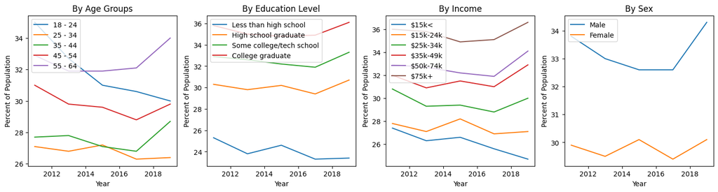

```python
make_plot("Q045", "US")
```

### Percent of adults who engage in muscle-strengthening activities on 2 or more days a week

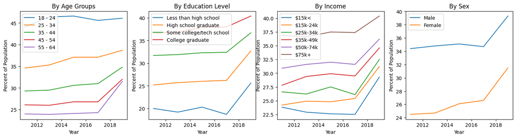

```python
make_plot("Q046", "US")
```

### Percent of adults who engage in no leisure-time physical activity

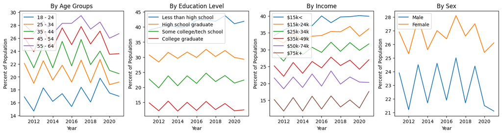

```python
make_plot("Q047", "US")
```

### Percent of adults who report consuming fruit less than one time daily

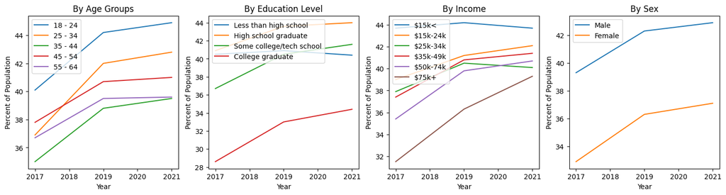

```python
make_plot("Q018", "US")
```

### Percent of adults who report consuming vegetables less than one time daily

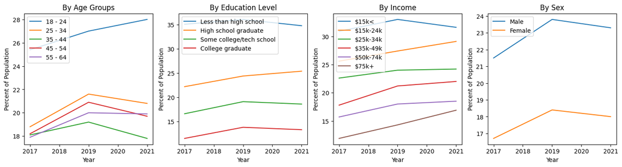

```python
make_plot("Q019", "US")
```

## Analysis, Hypothesis Testing and Machine Learning

[output not shown]